# final-xgboost

```r
library(tidyverse) # everything
library(reshape2) # melting tables
library(caret) # training, cross-validation, hyperparameter search
library(xgboost) # XGBoost
library(Matrix) # XGBoost sparse matrices
library(tictoc) # timing models
library(PRROC) # AUROC and AUPRC
library(smotefamily) # synthetic minority over-sampling
library(ROSE) # random majority under-sampling
library(gridExtra) # combining graphs

theme_set(theme_light()) # cleaner graphs

data <- data.table::fread("../input/creditcardfraud/creditcard.csv")
data$Class <- factor(ifelse(data$Class == 0, "zero", "one")) # creates issues later in caret if using 0, 1
```

```r
data$Time <- NULL
```

Variables V1 - V28 are the principal components from PCA and should be uncorrelated. We will check this.

```r
pca_corr <- round(cor(data[ ,1:28]), 3)

max(abs(pca_corr)[upper.tri(pca_corr)])
```

0

```r
predictors <- select(data, -Class)

cbind(melt(apply(predictors, 2, min), value.name = "min"),
      melt(apply(predictors, 2, max), value.name = "max"))
```

A data.frame: 29 × 2

|  | min <dbl> | max <dbl> |
| --- | --- | --- |
| V1 | -56.407510 | 2.454930 |
| V2 | -72.715728 | 22.057729 |
| V3 | -48.325589 | 9.382558 |
| V4 | -5.683171 | 16.875344 |
| V5 | -113.743307 | 34.801666 |
| V6 | -26.160506 | 73.301626 |
| V7 | -43.557242 | 120.589494 |
| V8 | -73.216718 | 20.007208 |
| V9 | -13.434066 | 15.594995 |
| V10 | -24.588262 | 23.745136 |
| V11 | -4.797473 | 12.018913 |
| V12 | -18.683715 | 7.848392 |
| V13 | -5.791881 | 7.126883 |
| V14 | -19.214325 | 10.526766 |
| V15 | -4.498945 | 8.877742 |
| V16 | -14.129855 | 17.315112 |
| V17 | -25.162799 | 9.253526 |
| V18 | -9.498746 | 5.041069 |
| V19 | -7.213527 | 5.591971 |
| V20 | -54.497720 | 39.420904 |
| V21 | -34.830382 | 27.202839 |
| V22 | -10.933144 | 10.503090 |
| V23 | -44.807735 | 22.528412 |
| V24 | -2.836627 | 4.584549 |
| V25 | -10.295397 | 7.519589 |
| V26 | -2.604551 | 3.517346 |
| V27 | -22.565679 | 31.612198 |
| V28 | -15.430084 | 33.847808 |
| Amount | 0.000000 | 25691.160000 |

Rescaling data such that all the variables are in the same range

```r
rescale <- function(x) {
  return((x - min(x)) / (max(x) - min(x)))
}

predictors_rescaled <- as.data.frame(apply(predictors, 2, rescale))

cbind(melt(apply(predictors_rescaled, 2, min), value.name = "min_after_rescaling"),
      melt(apply(predictors_rescaled, 2, max), value.name = "max_after_rescaling"))
```

A data.frame: 29 × 2

|  | min_after_rescaling <dbl> | max_after_rescaling <dbl> |
| --- | --- | --- |
| V1 | 0 | 1 |
| V2 | 0 | 1 |
| V3 | 0 | 1 |
| V4 | 0 | 1 |
| V5 | 0 | 1 |
| V6 | 0 | 1 |
| V7 | 0 | 1 |
| V8 | 0 | 1 |
| V9 | 0 | 1 |
| V10 | 0 | 1 |
| V11 | 0 | 1 |
| V12 | 0 | 1 |
| V13 | 0 | 1 |
| V14 | 0 | 1 |
| V15 | 0 | 1 |
| V16 | 0 | 1 |
| V17 | 0 | 1 |
| V18 | 0 | 1 |
| V19 | 0 | 1 |
| V20 | 0 | 1 |
| V21 | 0 | 1 |
| V22 | 0 | 1 |
| V23 | 0 | 1 |
| V24 | 0 | 1 |
| V25 | 0 | 1 |
| V26 | 0 | 1 |
| V27 | 0 | 1 |
| V28 | 0 | 1 |
| Amount | 0 | 1 |

```r
data <- cbind(Class = data$Class, predictors_rescaled)
```

We are testing SMOTE in conjunction with randomized under-sampling (RUS) as it will cut down computation time significantly, and can lead to better test-set performance in ROC space than the normal imbalanced data.

SMOTE uses KNN to generate synthetic examples, and the default nearest neighbours is K = 5. We’ll be sticking to this default throughout the analysis.

The steps SMOTE takes to generate synthetic minority (fraud) samples are as follows:

- Choose a minority case: X
- Find K nearest neighbors (in euclidean distance, as default) of X: X1, …, X5
- Randomly choose one of these K minority neighbors: X4
- Generate a random number between 0 and 1: i
- Create a synthetic minority observation somewhere ‘between’ the 2 points: X + i(X4 - X)
- Repeat dup_size times for each fraud case in the dataset. e.g. for dup_size = 1, SMOTE adds 1 synthetic fraud case for each real fraud case

```r
set.seed(23)
sample <- sample_n(data, 10000)


# 1) generating 4 synthetic minority samples for every 1 legitimate
sample_smote <- SMOTE(X = sample[, -1],
                      target = sample$Class,
                      dup_size = 4)

sample_smote_data <- sample_smote$data
sample_smote_data$class <- factor(sample_smote_data$class)
```

```r
table(sample$Class)
```

```
 one zero
  19 9981
```

```r
table(sample_smote_data$class)
```

```
 one zero
  95 9981
```

For majority undersampling, the methodology is pretty intuitive - majority (non-fraud) cases are randomly removed from the dataset until the desired overall volume is reached.

```r
# 2) now randomly undersampling majority
sample_smote_under <- ovun.sample(class ~ .,
                                  data = sample_smote_data,
                                  method = "under",
                                  N = nrow(sample_smote_data[sample_smote_data$class == "one", ]) * 11)

sample_smote_under_data <- sample_smote_under$data
# levels(sample_smote_under_data$class)
sample_smote_under_data$class <- relevel(sample_smote_under_data$class, ref = "one")
```

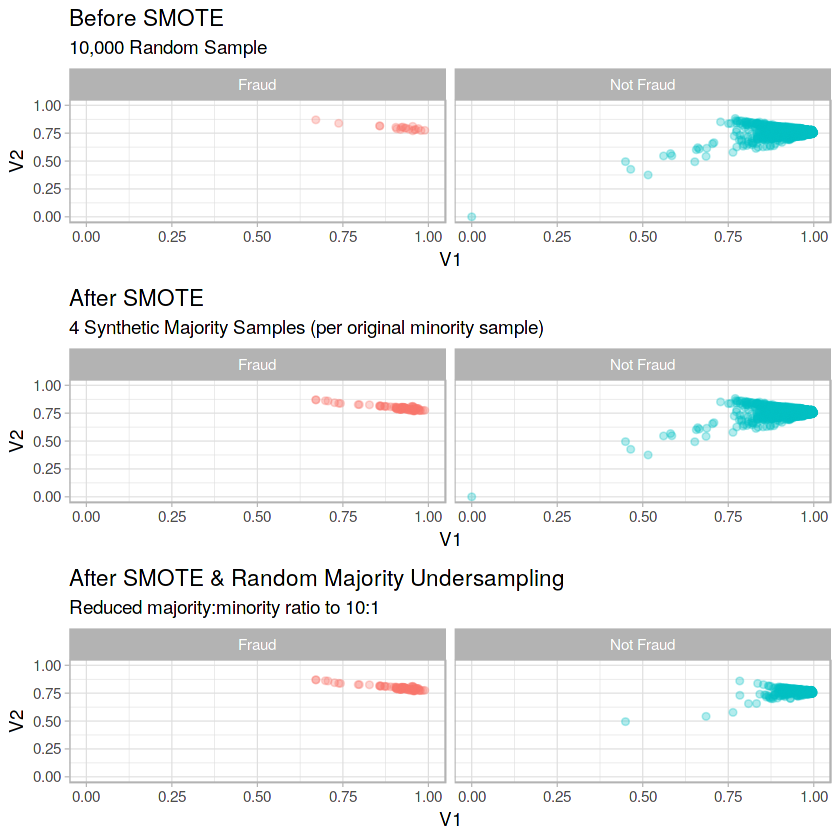

```r
p1 <- ggplot(sample, aes(x = V1, y = V2, col = Class)) +
  geom_point(alpha = 0.3) +
  facet_wrap(~ Class, labeller = labeller(Class = c(one = "Fraud", zero = "Not Fraud"))) +
  labs(title = "Before SMOTE",
       subtitle = "10,000 Random Sample",
       col = "Class") +
  scale_x_continuous(limits = c(0, 1)) +
  scale_y_continuous(limits = c(0, 1)) +
  theme(legend.position = "none")

p2 <- ggplot(sample_smote_data, aes(x = V1, y = V2, col = class)) +
  geom_point(alpha = 0.3) +
  facet_wrap(~ class, labeller = labeller(class = c(one = "Fraud", zero = "Not Fraud"))) +
  labs(title = "After SMOTE",
       subtitle = "4 Synthetic Majority Samples (per original minority sample)",
       col = "Class") +
  scale_x_continuous(limits = c(0, 1)) +
  scale_y_continuous(limits = c(0, 1)) +
  theme(legend.position = "none")

p3 <- ggplot(sample_smote_under_data, aes(x = V1, y = V2, col = class)) +
  geom_point(alpha = 0.3) +
  facet_wrap(~ class, labeller = labeller(class = c(one = "Fraud", zero = "Not Fraud"))) +
  labs(title = "After SMOTE & Random Majority Undersampling",
       subtitle = "Reduced majority:minority ratio to 10:1",
       col = "Class") +
  scale_x_continuous(limits = c(0, 1)) +
  scale_y_continuous(limits = c(0, 1)) +
  theme(legend.position = "none")

grid.arrange(p1, p2, p3, nrow = 3)
```

# Train/Test Split

We're going to test model performance on the unaltered dataset against 6 different combinations of SMOTE & RUS.

We should only be applying the sampling techniques to the training dataset, and model performance should be evaluated on an un-altered test set.

1. The unaltered, highly class-imbalanced dataset, train

```r
set.seed(23)

train_index <- createDataPartition(data$Class, p=0.75, list=FALSE)

train <- data[train_index, ] # training data (75% of data)
test <- data[-train_index, ] # testing data (25% of data)
```

1. A balanced dataset with less up-sampling, train_v1

```r
set.seed(23)
smote_v1 <- SMOTE(X = train[, -1], target = train$Class, dup_size = 4) # generating 4 synthetic minority samples for every 1 legitimate
smote_train_v1 <- smote_v1$data %>% rename(Class = class)

# under-sample until majority sample size matches
under_v1 <- ovun.sample(Class ~ .,
                        data = smote_train_v1,
                        method = "under",
                        N = 2 * sum(smote_train_v1$Class == "one"))

train_v1 <- under_v1$data
```

1. A balanced dataset with more up-sampling, train_v2

```r
set.seed(23)
smote_v2 <- SMOTE(X = train[, -1], target = train$Class, dup_size = 29)
smote_train_v2 <- smote_v2$data %>% rename(Class = class)

under_v2 <- ovun.sample(Class ~ .,
                        data = smote_train_v2,
                        method = "under",
                        N = 2 * sum(smote_train_v2$Class == "one"))

train_v2 <- under_v2$data
```

1. A fraud-majority dataset with less up-sampling, train_v3

```r
set.seed(23)
smote_v3 <- SMOTE(X = train[, -1], target = train$Class, dup_size = 4)
smote_train_v3 <- smote_v3$data %>% rename(Class = class)

under_v3 <- ovun.sample(Class ~ .,
                        data = smote_train_v3,
                        method = "under",
                        N = round(sum(smote_train_v3$Class == "one") * (4/3)))

train_v3 <- under_v3$data
```

1. A fraud-majority dataset with more up-sampling, train_v4

```r
set.seed(23)
smote_v4 <- SMOTE(X = train[, -1], target = train$Class, dup_size = 29)
smote_train_v4 <- smote_v4$data %>% rename(Class = class)

under_v4 <- ovun.sample(Class ~ .,
                        data = smote_train_v4,
                        method = "under",
                        N = round(sum(smote_train_v4$Class == "one") * (4/3)))

train_v4 <- under_v4$data
```

1. A fraud-minority dataset with less up-sampling, train_v5

```r
set.seed(23)
smote_v5 <- SMOTE(X = train[, -1], target = train$Class, dup_size = 4)
smote_train_v5 <- smote_v5$data %>% rename(Class = class)

under_v5 <- ovun.sample(Class ~ .,
                        data = smote_train_v5,
                        method = "under",
                        N = (sum(smote_train_v5$Class == "one") * 4))

train_v5 <- under_v5$data
```

1. A fraud-minority dataset with more up-sampling, train_v6

```r
set.seed(23)
smote_v6 <- SMOTE(X = train[, -1], target = train$Class, dup_size = 29)
smote_train_v6 <- smote_v6$data %>% rename(Class = class)

under_v6 <- ovun.sample(Class ~ .,
                        data = smote_train_v6,
                        method = "under",
                        N = (sum(smote_train_v6$Class == "one") * 4))

train_v6 <- under_v6$data
```

```r
table(train_v1$Class)
```

```
 one zero
1845 1845
```

```r
table(train_v2$Class)
```

```
  one  zero
11070 11070
```

```r
table(train$Class)
```

```
   one   zero
   369 213237
```

```r
train_datasets <- list(train = train,
                       train_v1 = train_v1,
                       train_v2 = train_v2,
                       train_v3 = train_v3,
                       train_v4 = train_v4,
                       train_v5 = train_v5,
                       train_v6 = train_v6
                       )

dataset <- 0
obs <- 0
frauds <- 0
frauds_perc <- 0

for (i in 1:7) {
  dataset[i] <- names(train_datasets)[i]
  obs[i] <- nrow(train_datasets[[i]])
  frauds[i] <- sum(train_datasets[[i]]$Class == "one")
  frauds_perc[i] <- frauds[i] / obs[i]
}
```

```r
obs
```

1. 213606

2. 3690

3. 22140

4. 2460

5. 14760

6. 7380

7. 44280

```r
(train_datasets_summary <- data.frame(name = dataset,
                                     num_obs = obs,
                                     frauds = frauds,
                                     frauds_perc = frauds_perc,
                                     weighting = c("original (very imbalanced)", "balanced", "balanced", "mostly fraud", "mostly fraud", "mostly non-fraud", "mostly non-fraud"),
                                     smote_amt = c("none", "some", "lots", "some", "lots", "some", "lots")))
```

A data.frame: 7 × 6

| name <fct> | num_obs <dbl> | frauds <dbl> | frauds_perc <dbl> | weighting <fct> | smote_amt <fct> |
| --- | --- | --- | --- | --- | --- |
| train | 213606 | 369 | 0.00172748 | original (very imbalanced) | none |
| train_v1 | 3690 | 1845 | 0.50000000 | balanced | some |
| train_v2 | 22140 | 11070 | 0.50000000 | balanced | lots |
| train_v3 | 2460 | 1845 | 0.75000000 | mostly fraud | some |
| train_v4 | 14760 | 11070 | 0.75000000 | mostly fraud | lots |
| train_v5 | 7380 | 1845 | 0.25000000 | mostly non-fraud | some |
| train_v6 | 44280 | 11070 | 0.25000000 | mostly non-fraud | lots |

I create 4 sparse matrices for XGBoost - the 3 training datasets and the test dataset.

```r
xgb_train <- sparse.model.matrix(Class ~ . -1, data = train)
xgb_train_v1 <- sparse.model.matrix(Class ~ . -1, data = train_v1)
xgb_train_v2 <- sparse.model.matrix(Class ~ . -1, data = train_v2)
xgb_test <- sparse.model.matrix(Class ~ . -1, data = test)

ctrl_xgb <- trainControl(method = "cv",
                         number = 3, # 3-fold cross-validation
                         summaryFunction=prSummary, # area under precision-recall curve
                         classProbs=TRUE,
                         allowParallel = TRUE)
```

```r
xgb_train_v3 <- sparse.model.matrix(Class ~ . -1, data = train_v3)
xgb_train_v4 <- sparse.model.matrix(Class ~ . -1, data = train_v4)
xgb_train_v5 <- sparse.model.matrix(Class ~ . -1, data = train_v5)
xgb_train_v6 <- sparse.model.matrix(Class ~ . -1, data = train_v6)
```

‘train’ - Full Dataset

```r
tic()
set.seed(23)
xgb_train_benchmark <- train(x = xgb_train,
                             y = train$Class,
                             method = "xgbTree",
                             metric = "AUC",
                             trControl = ctrl_xgb)
toc()
```

```
3000.431 sec elapsed
```

```r
xgb_train_pred <- predict(xgb_train_benchmark, xgb_test, type = "prob")

xgb_train_scores <- data.frame(event_prob = xgb_train_pred$one, labels = test$Class)

xgb_train_roc <- PRROC::roc.curve(scores.class0 = xgb_train_scores[xgb_train_scores$labels == "one", ]$event_prob, # scores for the POSITIVE class
                           scores.class1 = xgb_train_scores[xgb_train_scores$labels == "zero", ]$event_prob, # scores for the NEGATIVE class
                           curve=T)

xgb_train_auprc <- PRROC::pr.curve(scores.class0 = xgb_train_scores[xgb_train_scores$labels == "one", ]$event_prob, # scores for the POSITIVE class
                            scores.class1 = xgb_train_scores[xgb_train_scores$labels == "zero", ]$event_prob, # scores for the NEGATIVE class
                            curve=T)

xgb_train_benchmark$bestTune
```

A data.frame: 1 × 7

|  | nrounds <dbl> | max_depth <int> | eta <dbl> | gamma <dbl> | colsample_bytree <dbl> | min_child_weight <dbl> | subsample <dbl> |
| --- | --- | --- | --- | --- | --- | --- | --- |
| 96 | 150 | 3 | 0.4 | 0 | 0.6 | 1 | 0.75 |

```r
paste("Area under the Precision-Recall curve:", round(xgb_train_auprc$auc.integral, 7))
```

'Area under the Precision-Recall curve: 0.813278'

```r
paste("Area under the ROC curve:", round(xgb_train_roc$auc, 7))
```

'Area under the ROC curve: 0.9786844'

‘train_v1’ - Small, Balanced (50:50)

```r
tic()
set.seed(23)
xgb_train_v1_benchmark <- train(x = xgb_train_v1,
                                y = train_v1$Class,
                                method = "xgbTree",
                                metric = "AUC",
                                trControl = ctrl_xgb)
toc()
```

```
59.476 sec elapsed
```

```r
xgb_train_v1_pred <- predict(xgb_train_v1_benchmark, xgb_test, type = "prob")

xgb_train_v1_scores <- data.frame(event_prob = xgb_train_v1_pred$one, labels = test$Class)

xgb_train_v1_roc <- PRROC::roc.curve(scores.class0 = xgb_train_v1_scores[xgb_train_v1_scores$labels == "one", ]$event_prob,
                              scores.class1 = xgb_train_v1_scores[xgb_train_v1_scores$labels == "zero", ]$event_prob,
                              curve=T)

xgb_train_v1_auprc <- PRROC::pr.curve(scores.class0 = xgb_train_v1_scores[xgb_train_v1_scores$labels == "one", ]$event_prob,
                               scores.class1 = xgb_train_v1_scores[xgb_train_v1_scores$labels == "zero", ]$event_prob,
                               curve=T)

xgb_train_v1_benchmark$bestTune
```

A data.frame: 1 × 7

|  | nrounds <dbl> | max_depth <int> | eta <dbl> | gamma <dbl> | colsample_bytree <dbl> | min_child_weight <dbl> | subsample <dbl> |
| --- | --- | --- | --- | --- | --- | --- | --- |
| 108 | 150 | 3 | 0.4 | 0 | 0.8 | 1 | 1 |

```r
paste("Area under the Precision-Recall curve:", round(xgb_train_v1_auprc$auc.integral, 7))
```

'Area under the Precision-Recall curve: 0.7888482'

```r
paste("Area under the ROC curve:", round(xgb_train_v1_roc$auc, 7))
```

'Area under the ROC curve: 0.9806845'

‘train_v2’ - Larger, Balanced (50:50)

```r
tic()
set.seed(23)
xgb_train_v2_benchmark <- train(x = xgb_train_v2,
                                y = train_v2$Class,
                                method = "xgbTree",
                                metric = "AUC",
                                trControl = ctrl_xgb)
toc()
```

```
310.449 sec elapsed
```

```r
xgb_train_v2_pred <- predict(xgb_train_v2_benchmark, xgb_test, type = "prob")

xgb_train_v2_scores <- data.frame(event_prob = xgb_train_v2_pred$one, labels = test$Class)

xgb_train_v2_roc <- PRROC::roc.curve(scores.class0 = xgb_train_v2_scores[xgb_train_v2_scores$labels == "one", ]$event_prob,
                              scores.class1 = xgb_train_v2_scores[xgb_train_v2_scores$labels == "zero", ]$event_prob,
                              curve=T)

xgb_train_v2_auprc <- PRROC::pr.curve(scores.class0 = xgb_train_v2_scores[xgb_train_v2_scores$labels == "one", ]$event_prob,
                               scores.class1 = xgb_train_v2_scores[xgb_train_v2_scores$labels == "zero", ]$event_prob,
                               curve=T)

xgb_train_v2_benchmark$bestTune
```

A data.frame: 1 × 7

|  | nrounds <dbl> | max_depth <int> | eta <dbl> | gamma <dbl> | colsample_bytree <dbl> | min_child_weight <dbl> | subsample <dbl> |
| --- | --- | --- | --- | --- | --- | --- | --- |
| 44 | 100 | 3 | 0.3 | 0 | 0.6 | 1 | 1 |

```r
paste("Area under the Precision-Recall curve:", round(xgb_train_v2_auprc$auc.integral, 7))
```

'Area under the Precision-Recall curve: 0.7783631'

```r
paste("Area under the ROC curve:", round(xgb_train_v2_roc$auc, 7))
```

'Area under the ROC curve: 0.9720965'

‘train_v3’ - Small, Fraud-Majority (75:25)

```r
tic()
set.seed(23)
xgb_train_v3_benchmark <- train(x = xgb_train_v3,
                                y = train_v3$Class,
                                method = "xgbTree",
                                metric = "AUC",
                                trControl = ctrl_xgb)
toc()
```

```
36.433 sec elapsed
```

```r
xgb_train_v3_pred <- predict(xgb_train_v3_benchmark, xgb_test, type = "prob")

xgb_train_v3_scores <- data.frame(event_prob = xgb_train_v3_pred$one, labels = test$Class)

xgb_train_v3_roc <- PRROC::roc.curve(scores.class0 = xgb_train_v3_scores[xgb_train_v3_scores$labels == "one", ]$event_prob,
                              scores.class1 = xgb_train_v3_scores[xgb_train_v3_scores$labels == "zero", ]$event_prob,
                              curve=T)

xgb_train_v3_auprc <- PRROC::pr.curve(scores.class0 = xgb_train_v3_scores[xgb_train_v3_scores$labels == "one", ]$event_prob,
                               scores.class1 = xgb_train_v3_scores[xgb_train_v3_scores$labels == "zero", ]$event_prob,
                               curve=T)

xgb_train_v3_benchmark$bestTune
```

A data.frame: 1 × 7

|  | nrounds <dbl> | max_depth <int> | eta <dbl> | gamma <dbl> | colsample_bytree <dbl> | min_child_weight <dbl> | subsample <dbl> |
| --- | --- | --- | --- | --- | --- | --- | --- |
| 45 | 150 | 3 | 0.3 | 0 | 0.6 | 1 | 1 |

```r
paste("Area under the Precision-Recall curve:", round(xgb_train_v3_auprc$auc.integral, 7))
```

'Area under the Precision-Recall curve: 0.7456798'

```r
paste("Area under the ROC curve:", round(xgb_train_v3_roc$auc, 7))
```

'Area under the ROC curve: 0.9813961'

‘train_v4’ - Larger, Fraud-Majority (75:25)

```r
tic()
set.seed(23)
xgb_train_v4_benchmark <- train(x = xgb_train_v4,
                                y = train_v4$Class,
                                method = "xgbTree",
                                metric = "AUC",
                                trControl = ctrl_xgb)
toc()
```

```
204.963 sec elapsed
```

```r
xgb_train_v4_pred <- predict(xgb_train_v4_benchmark, xgb_test, type = "prob")

xgb_train_v4_scores <- data.frame(event_prob = xgb_train_v4_pred$one, labels = test$Class)

xgb_train_v4_roc <- PRROC::roc.curve(scores.class0 = xgb_train_v4_scores[xgb_train_v4_scores$labels == "one", ]$event_prob,
                              scores.class1 = xgb_train_v4_scores[xgb_train_v4_scores$labels == "zero", ]$event_prob,
                              curve=T)

xgb_train_v4_auprc <- PRROC::pr.curve(scores.class0 = xgb_train_v4_scores[xgb_train_v4_scores$labels == "one", ]$event_prob,
                               scores.class1 = xgb_train_v4_scores[xgb_train_v4_scores$labels == "zero", ]$event_prob,
                               curve=T)

xgb_train_v4_benchmark$bestTune
```

A data.frame: 1 × 7

|  | nrounds <dbl> | max_depth <int> | eta <dbl> | gamma <dbl> | colsample_bytree <dbl> | min_child_weight <dbl> | subsample <dbl> |
| --- | --- | --- | --- | --- | --- | --- | --- |
| 30 | 150 | 2 | 0.3 | 0 | 0.8 | 1 | 0.5 |

```r
paste("Area under the Precision-Recall curve:", round(xgb_train_v4_auprc$auc.integral, 7))
```

'Area under the Precision-Recall curve: 0.7507508'

```r
paste("Area under the ROC curve:", round(xgb_train_v4_roc$auc, 7))
```

'Area under the ROC curve: 0.9781763'

‘train_v5’ - Smaller, Fraud-Minority (25:75)

```r
tic()
set.seed(23)
xgb_train_v5_benchmark <- train(x = xgb_train_v5,
                                y = train_v5$Class,
                                method = "xgbTree",
                                metric = "AUC",
                                trControl = ctrl_xgb)
toc()
```

```
108.31 sec elapsed
```

```r
xgb_train_v5_pred <- predict(xgb_train_v5_benchmark, xgb_test, type = "prob")

xgb_train_v5_scores <- data.frame(event_prob = xgb_train_v5_pred$one, labels = test$Class)

xgb_train_v5_roc <- PRROC::roc.curve(scores.class0 = xgb_train_v5_scores[xgb_train_v5_scores$labels == "one", ]$event_prob,
                                     scores.class1 = xgb_train_v5_scores[xgb_train_v5_scores$labels == "zero", ]$event_prob,
                                     curve=T)

xgb_train_v5_auprc <- PRROC::pr.curve(scores.class0 = xgb_train_v5_scores[xgb_train_v5_scores$labels == "one", ]$event_prob,
                                      scores.class1 = xgb_train_v5_scores[xgb_train_v5_scores$labels == "zero", ]$event_prob,
                                      curve=T)

xgb_train_v5_benchmark$bestTune
```

A data.frame: 1 × 7

|  | nrounds <dbl> | max_depth <int> | eta <dbl> | gamma <dbl> | colsample_bytree <dbl> | min_child_weight <dbl> | subsample <dbl> |
| --- | --- | --- | --- | --- | --- | --- | --- |
| 108 | 150 | 3 | 0.4 | 0 | 0.8 | 1 | 1 |

```r
paste("Area under the Precision-Recall curve:", round(xgb_train_v5_auprc$auc.integral, 7))
```

'Area under the Precision-Recall curve: 0.7630569'

```r
paste("Area under the ROC curve:", round(xgb_train_v5_roc$auc, 7))
```

'Area under the ROC curve: 0.9816239'

‘train_v6’ - Larger, Fraud-Minority (25:75)

```r
tic()
set.seed(23)
xgb_train_v6_benchmark <- train(x = xgb_train_v6,
                                y = train_v6$Class,
                                method = "xgbTree",
                                metric = "AUC",
                                trControl = ctrl_xgb)
toc()
```

```
621.038 sec elapsed
```

```r
xgb_train_v6_pred <- predict(xgb_train_v6_benchmark, xgb_test, type = "prob")

xgb_train_v6_scores <- data.frame(event_prob = xgb_train_v6_pred$one, labels = test$Class)

xgb_train_v6_roc <- PRROC::roc.curve(scores.class0 = xgb_train_v6_scores[xgb_train_v6_scores$labels == "one", ]$event_prob,
                                     scores.class1 = xgb_train_v6_scores[xgb_train_v6_scores$labels == "zero", ]$event_prob,
                                     curve=T)

xgb_train_v6_auprc <- PRROC::pr.curve(scores.class0 = xgb_train_v6_scores[xgb_train_v6_scores$labels == "one", ]$event_prob,
                                      scores.class1 = xgb_train_v6_scores[xgb_train_v6_scores$labels == "zero", ]$event_prob,
                                      curve=T)

xgb_train_v6_benchmark$bestTune
```

A data.frame: 1 × 7

|  | nrounds <dbl> | max_depth <int> | eta <dbl> | gamma <dbl> | colsample_bytree <dbl> | min_child_weight <dbl> | subsample <dbl> |
| --- | --- | --- | --- | --- | --- | --- | --- |
| 95 | 100 | 3 | 0.4 | 0 | 0.6 | 1 | 0.75 |

```r
paste("Area under the Precision-Recall curve:", round(xgb_train_v6_auprc$auc.integral, 7))
```

'Area under the Precision-Recall curve: 0.795022'

```r
paste("Area under the ROC curve:", round(xgb_train_v6_roc$auc, 7))
```

'Area under the ROC curve: 0.9799994'

```r
train_datasets_model_summary <- cbind(train_datasets_summary,
                                      AUPRC = c(xgb_train_auprc$auc.integral,
                                                xgb_train_v1_auprc$auc.integral,
                                                xgb_train_v2_auprc$auc.integral,
                                                xgb_train_v3_auprc$auc.integral,
                                                xgb_train_v4_auprc$auc.integral,
                                                xgb_train_v5_auprc$auc.integral,
                                                xgb_train_v6_auprc$auc.integral),
                                      ROC_AUC = c(xgb_train_roc$auc,
                                                  xgb_train_v1_roc$auc,
                                                  xgb_train_v2_roc$auc,
                                                  xgb_train_v3_roc$auc,
                                                  xgb_train_v4_roc$auc,
                                                  xgb_train_v5_roc$auc,
                                                  xgb_train_v6_roc$auc))
train_datasets_model_summary
```

A data.frame: 7 × 8

| name <fct> | num_obs <dbl> | frauds <dbl> | frauds_perc <dbl> | weighting <fct> | smote_amt <fct> | AUPRC <dbl> | ROC_AUC <dbl> |
| --- | --- | --- | --- | --- | --- | --- | --- |
| train | 213606 | 369 | 0.00172748 | original (very imbalanced) | none | 0.8132780 | 0.9786844 |
| train_v1 | 3690 | 1845 | 0.50000000 | balanced | some | 0.7888482 | 0.9806845 |
| train_v2 | 22140 | 11070 | 0.50000000 | balanced | lots | 0.7783631 | 0.9720965 |
| train_v3 | 2460 | 1845 | 0.75000000 | mostly fraud | some | 0.7456798 | 0.9813961 |
| train_v4 | 14760 | 11070 | 0.75000000 | mostly fraud | lots | 0.7507508 | 0.9781763 |
| train_v5 | 7380 | 1845 | 0.25000000 | mostly non-fraud | some | 0.7630569 | 0.9816239 |
| train_v6 | 44280 | 11070 | 0.25000000 | mostly non-fraud | lots | 0.7950220 | 0.9799994 |

Below we can see the precision-recall curves for each model:

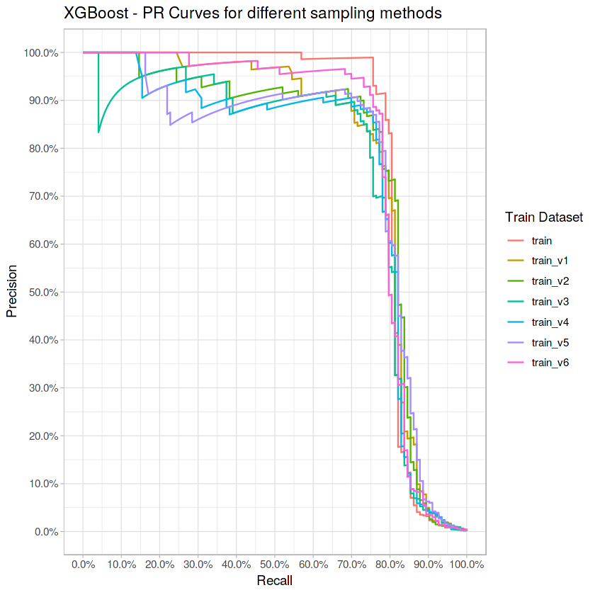

```r
xgb_train_prcurve <- cbind(as.data.frame(xgb_train_auprc$curve), dataset = "train")
xgb_train_v1_prcurve <- cbind(as.data.frame(xgb_train_v1_auprc$curve), dataset = "train_v1")
xgb_train_v2_prcurve <- cbind(as.data.frame(xgb_train_v2_auprc$curve), dataset = "train_v2")
xgb_train_v3_prcurve <- cbind(as.data.frame(xgb_train_v3_auprc$curve), dataset = "train_v3")
xgb_train_v4_prcurve <- cbind(as.data.frame(xgb_train_v4_auprc$curve), dataset = "train_v4")
xgb_train_v5_prcurve <- cbind(as.data.frame(xgb_train_v5_auprc$curve), dataset = "train_v5")
xgb_train_v6_prcurve <- cbind(as.data.frame(xgb_train_v6_auprc$curve), dataset = "train_v6")

pr_curve_plot <- rbind(xgb_train_prcurve, xgb_train_v1_prcurve, xgb_train_v2_prcurve, xgb_train_v3_prcurve, xgb_train_v4_prcurve, xgb_train_v5_prcurve, xgb_train_v6_prcurve)

pr_curve_plot %>%
  arrange(dataset, V1, desc(V2)) %>% # makes the graph nicer, so it has vertical downward spikes instead of upward spikes
  ggplot(aes(x = V1, y = V2, col = factor(dataset))) +
  geom_line() +
  scale_x_continuous(breaks = seq(0, 1, 0.1), labels = scales::percent) +
  scale_y_continuous(breaks = seq(0, 1, 0.1), labels = scales::percent) +
  labs(title = "XGBoost - PR Curves for different sampling methods",
       x = "Recall",
       y = "Precision",
       col = "Train Dataset")
```

We can also see the ROC curves:

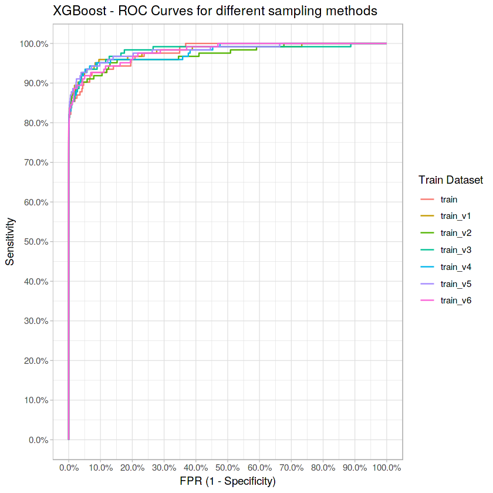

```r
xgb_train_roccurve <- cbind(as.data.frame(xgb_train_roc$curve), dataset = "train")
xgb_train_v1_roccurve <- cbind(as.data.frame(xgb_train_v1_roc$curve), dataset = "train_v1")
xgb_train_v2_roccurve <- cbind(as.data.frame(xgb_train_v2_roc$curve), dataset = "train_v2")
xgb_train_v3_roccurve <- cbind(as.data.frame(xgb_train_v3_roc$curve), dataset = "train_v3")
xgb_train_v4_roccurve <- cbind(as.data.frame(xgb_train_v4_roc$curve), dataset = "train_v4")
xgb_train_v5_roccurve <- cbind(as.data.frame(xgb_train_v5_roc$curve), dataset = "train_v5")
xgb_train_v6_roccurve <- cbind(as.data.frame(xgb_train_v6_roc$curve), dataset = "train_v6")

roc_curve_plot <- rbind(xgb_train_roccurve, xgb_train_v1_roccurve, xgb_train_v2_roccurve, xgb_train_v3_roccurve, xgb_train_v4_roccurve, xgb_train_v5_roccurve, xgb_train_v6_roccurve)

ggplot(roc_curve_plot, aes(x = V1, y = V2, col = factor(dataset))) +
  geom_line() +
  scale_x_continuous(breaks = seq(0, 1, 0.1), labels = scales::percent) +
  scale_y_continuous(breaks = seq(0, 1, 0.1), labels = scales::percent) +
  labs(title = "XGBoost - ROC Curves for different sampling methods",
       x = "FPR (1 - Specificity)",
       y = "Sensitivity",
       col = "Train Dataset")
```

The balanced datasets and those that maintained the fraud minority seemed to perform better than those where the class imbalance was reversed (to a fraud majority):

```r
train_datasets_model_summary %>%
  group_by(weighting) %>%
  summarize(avg_AUPRC = mean(AUPRC)) %>%
  arrange(desc(avg_AUPRC))
```

A tibble: 4 × 2

| weighting <fct> | avg_AUPRC <dbl> |
| --- | --- |
| original (very imbalanced) | 0.8132780 |
| balanced | 0.7836056 |
| mostly non-fraud | 0.7790395 |
| mostly fraud | 0.7482153 |

```r
train_datasets_model_summary %>%
  group_by(smote_amt) %>%
  summarize(avg_AUPRC = mean(AUPRC)) %>%
  arrange(desc(avg_AUPRC))
```

A tibble: 3 × 2

| smote_amt <fct> | avg_AUPRC <dbl> |
| --- | --- |
| none | 0.8132780 |
| lots | 0.7747120 |
| some | 0.7658616 |

From the previous graphs, it should be clear that PR curves can show differences in algorithm performance that are unclear for ROC curves

The reason for using PR curves here is essentially the high class imbalance present in the data:

```r
prop.table(table(data$Class))
```

```
        one        zero
0.001727486 0.998272514
```